# Analysis of General Mills

Ralitza Mondal

# 1 Clear the environment and load packages

```r
# Clear environment of variables and functions
rm(list = ls(all = TRUE))

# Clear environmet of packages
if(is.null(sessionInfo()$otherPkgs) == FALSE)lapply(paste("package:", names(sessionInfo()$otherPkgs), sep=""), detach, character.only = TRUE, unload = TRUE)
```

```r
library(tidyverse)
library(scales)
library(gridExtra)
library(janitor)
library(knitr)
library(GGally)
```

```r
library(stringr)
library(plotly)
```

# 2 Load the data

Load the qp1_data.csv data into df

```r
df<-read.csv('mtp_data.csv')
```

# 3 Base EDA Step 1: Univariate non-graphical EDA

Check the data type

```r
str(df)
```

```
## 'data.frame':    21850 obs. of  11 variables:
##  $ UPC    : Factor w/ 114 levels "00-01-16000-11653",..: 1 1 1 2 2 2 3 3 3 3 ...
##  $ iri_key: int  644347 248741 535806 675634 205272 248741 932600 278738 660222 644937 ...
##  $ week   : int  1484 1483 1489 1489 1491 1492 1517 1513 1523 1483 ...
##  $ units  : int  5 2 3 2 8 5 6 1 4 14 ...
##  $ brand  : Factor w/ 15 levels "GENERAL MILLS CHEERIOS",..: 2 2 2 1 1 1 2 2 2 2 ...
##  $ flavor : Factor w/ 5 levels "CINNAMON TOAST",..: 1 1 1 5 5 5 1 1 1 1 ...
##  $ package: Factor w/ 2 levels "BOX","CUP": 1 1 1 1 1 1 2 2 2 2 ...
##  $ volume : num  0.06 0.06 0.06 0.04 0.04 0.04 0.12 0.12 0.12 0.12 ...
##  $ price  : num  0.5 0.5 0.5 0.5 0.5 0.5 1.09 1.59 1.59 1 ...
##  $ promo  : int  0 0 0 0 0 0 0 0 0 0 ...
##  $ ad     : Factor w/ 3 levels "A","B","NONE": 1 3 3 3 3 3 3 3 3 3 ...
```

Change some integers to factors

```r
df$promo <- as.factor(df$promo)
df$week<-as.factor(df$week)
df$revenue<-as.integer(df$price)*as.integer(df$units)
kellogs <- df[which(str_detect(df$brand, "KELLOGGS")),]
gm <- df[which(str_detect(df$brand, "GENERAL MILLS")),]
post <- df[which(str_detect(df$brand, "POST")),]

extractTitle <- function(brand) {
  brand <- as.character(brand)

  if (length(grep("KELLOGGS", brand)) > 0) {
    return ("KELLOGGS")
  } else if (length(grep("GENERAL MILLS", brand)) > 0) {
    return ("GENERAL MILLS")
  } else if (length(grep("POST", brand)) > 0) {
    return ("POST")
  } else {
    return ("Other")
  }
}

Producers <- NULL
for (i in 1:nrow(df)) {
  Producers <- c(Producers, extractTitle(df[i,"brand"]))
}
df$Producers <- as.factor(Producers)

levels(df$week) <- c("1","2","3","4","5","6","7","8","9","10","11","12",
                     "13","14","15","16","17","18","19","20","21","22",
                     "23","24","25","26","27","28","29","30","31","32","33",
                     "34","35","36","37","38","39","40","41","42","43","44",
                     "45","46","47","48","49","50","51","52")
str(df)
```

```
## 'data.frame':    21850 obs. of  13 variables:
##  $ UPC      : Factor w/ 114 levels "00-01-16000-11653",..: 1 1 1 2 2 2 3 3 3 3 ...
##  $ iri_key  : int  644347 248741 535806 675634 205272 248741 932600 278738 660222 644937 ...
##  $ week     : Factor w/ 52 levels "1","2","3","4",..: 6 5 11 11 13 14 39 35 45 5 ...
##  $ units    : int  5 2 3 2 8 5 6 1 4 14 ...
##  $ brand    : Factor w/ 15 levels "GENERAL MILLS CHEERIOS",..: 2 2 2 1 1 1 2 2 2 2 ...
##  $ flavor   : Factor w/ 5 levels "CINNAMON TOAST",..: 1 1 1 5 5 5 1 1 1 1 ...
##  $ package  : Factor w/ 2 levels "BOX","CUP": 1 1 1 1 1 1 2 2 2 2 ...
##  $ volume   : num  0.06 0.06 0.06 0.04 0.04 0.04 0.12 0.12 0.12 0.12 ...
##  $ price    : num  0.5 0.5 0.5 0.5 0.5 0.5 1.09 1.59 1.59 1 ...
##  $ promo    : Factor w/ 2 levels "0","1": 1 1 1 1 1 1 1 1 1 1 ...
##  $ ad       : Factor w/ 3 levels "A","B","NONE": 1 3 3 3 3 3 3 3 3 3 ...
##  $ revenue  : int  0 0 0 0 0 0 6 1 4 14 ...
##  $ Producers: Factor w/ 3 levels "GENERAL MILLS",..: 1 1 1 1 1 1 1 1 1 1 ...
```

Comments:

UPC:kept UPC as factor as per originally given as these are unique product number

iri_key: kept it as int since converting into factors wouldnt make much sense as we would be having a factor with more than 420 levels

week: converted into factor variable since there are 52 unique weeks

units-volume-price-revenue:continuous variables

brand-flabour-package-promo-producers and ad: all factor variables

```r
summary(df)
```

```
##                 UPC           iri_key             week
##  00-01-43000-10521:  676   Min.   : 200171   22     :  475
##  00-01-38000-01621:  666   1st Qu.: 241553   12     :  473
##  00-01-38000-00828:  660   Median : 273720   37     :  464
##  00-01-16000-27569:  639   Mean   : 454405   29     :  449
##  00-02-38000-66330:  618   3rd Qu.: 648547   20     :  445
##  00-01-38000-01611:  612   Max.   :8057418   43     :  445
##  (Other)          :17979                     (Other):19099
##      units                                  brand
##  Min.   : 1.000   KELLOGGS FROSTED FLAKES      : 2295
##  1st Qu.: 3.000   KELLOGGS FROOT LOOPS         : 2192
##  Median : 7.000   GENERAL MILLS CINNAMON TST CR: 1834
##  Mean   : 8.579   GENERAL MILLS LUCKY CHARMS   : 1681
##  3rd Qu.:12.000   KELLOGGS FROSTED MINI WHEATS : 1574
##  Max.   :28.000   GENERAL MILLS CHEERIOS       : 1458
##                   (Other)                      :10816
##             flavor     package         volume          price
##  CINNAMON TOAST:1834   BOX:21306   Min.   :0.040   Min.   :0.250
##  COCOA         :1901   CUP:  544   1st Qu.:0.750   1st Qu.:3.190
##  FRUIT         :2192               Median :1.060   Median :3.790
##  REGULAR       :8816               Mean   :1.016   Mean   :3.763
##  TOASTED       :7107               3rd Qu.:1.120   3rd Qu.:4.390
##                                    Max.   :4.000   Max.   :9.990
##
##  promo        ad           revenue               Producers
##  0:17305   A   : 1456   Min.   :  0.00   GENERAL MILLS: 7189
##  1: 4545   B   : 1061   1st Qu.:  9.00   KELLOGGS     :12183
##            NONE:19333   Median : 21.00   POST         : 2478
##                         Mean   : 26.28
##                         3rd Qu.: 36.00
##                         Max.   :140.00
##
```

Comments:

We ignore the UPC and iri_key because there are identification numbers

we see that the top 6 weeks are 1490 above

units seem to be a bit skewed since mean is not equal to median

The top 6 brands seems to be contending between Kellogs and general mills

Regular seems to be the most popoular flavour

box packages sell more than cup

volume is also a little bit skewed since mean is not equal to median

price seem not to be skewed as much so taking the mean price would be okay

there are more no store promotion than promotions

Mostly there are no ads in store but ad A count is more than B

revenue looks skewed

Look for into the depth of the count in week and brand

```r
mean(table(df$week))
```

```
## [1] 420.1923
```

```r
median(table(df$week))
```

```
## [1] 421
```

```r
quantile(table(df$week))
```

```
##     0%    25%    50%    75%   100%
## 369.00 400.75 421.00 436.75 475.00
```

```r
table(df$week)
```

```
##
##   1   2   3   4   5   6   7   8   9  10  11  12  13  14  15  16  17  18
## 383 401 402 409 427 428 435 386 398 389 412 473 421 429 397 403 414 435
##  19  20  21  22  23  24  25  26  27  28  29  30  31  32  33  34  35  36
## 421 445 389 475 399 425 423 420 432 424 449 439 409 439 393 394 399 436
##  37  38  39  40  41  42  43  44  45  46  47  48  49  50  51  52
## 464 441 414 441 412 418 445 441 439 420 431 445 429 369 400 388
```

```r
table(df$brand)
```

```
##
##        GENERAL MILLS CHEERIOS GENERAL MILLS CINNAMON TST CR
##                          1458                          1834
##     GENERAL MILLS COCOA PUFFS             GENERAL MILLS KIX
##                          1020                          1196
##    GENERAL MILLS LUCKY CHARMS       KELLOGGS COCOA KRISPIES
##                          1681                           881
##          KELLOGGS FROOT LOOPS       KELLOGGS FROSTED FLAKES
##                          2192                          2295
##  KELLOGGS FROSTED MINI WHEATS          KELLOGGS RAISIN BRAN
##                          1574                          1266
##        KELLOGGS RICE KRISPIES          KELLOGGS SMART START
##                          1450                          1134
##            KELLOGGS SPECIAL K               POST GRAPE NUTS
##                          1391                          1289
##           POST SHREDDED WHEAT
##                          1189
```

*Comments:

Kelloggs Cocoa krispies sells the least

The count summary for the week doesn’t seem to be that skewed

# 4 Base EDA Step 2: Uni-variate graphical analysis

## 4.1 Quantitative variable

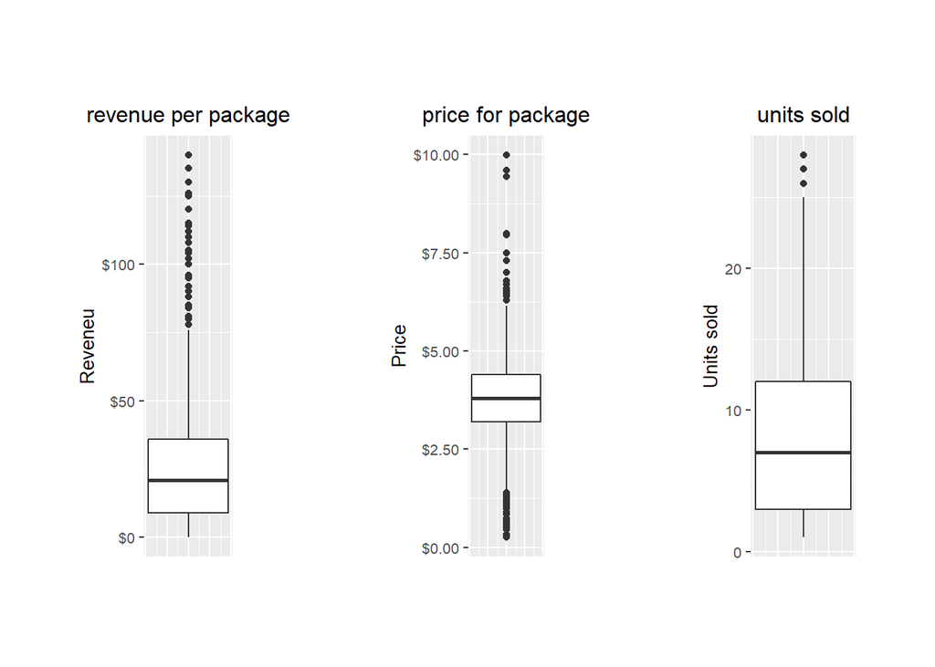

```r
grid.arrange(
ggplot(data = df) +
  geom_boxplot(mapping = aes(x = 1,y = revenue))+
  ggtitle('revenue per package')+
  labs(x = '', y = 'Reveneu')+
  scale_y_continuous(labels = scales::dollar)+
  theme(axis.title.x=element_blank(),
        axis.text.x=element_blank(),
        axis.ticks.x=element_blank(),#delete the x axis lables
        plot.title = element_text(hjust = 0.5),# title center
        text =  element_text(size=10),plot.margin = margin(2,1.5,2,1.5, "cm")),
ggplot(data = df) +
  geom_boxplot(mapping = aes(x = 1,y = price))+
  ggtitle('price for package')+
  labs(x = '', y = 'Price')+
  scale_y_continuous(labels = scales::dollar)+
  theme(axis.title.x=element_blank(),
        axis.text.x=element_blank(),
        axis.ticks.x=element_blank(),#delete the x axis lables
        plot.title = element_text(hjust = 0.5),# title center
        text =  element_text(size=10),plot.margin = margin(2,1.5,2,1.5, "cm")),
ggplot(data = df) +
  geom_boxplot(mapping = aes(x = 1,y = units))+
  ggtitle('units sold')+
  labs(x = '', y = 'Units sold')+
  theme(axis.title.x=element_blank(),
        axis.text.x=element_blank(),
        axis.ticks.x=element_blank(),#delete the x axis lables
        plot.title = element_text(hjust = 0.5),# title center
        text =  element_text(size=10),plot.margin = margin(2,1.5,2,1.5, "cm")),
ncol=3



)
```

*Comments:

There are outliers in prices above price of $6.25 and below $1.25

There are lots of outliers,more than outlier of prices; esp,for revenue above $75 which needs to be investigated maybe huge quantities are sold as median prices, where are these huge quantities coming from? What is their drive?

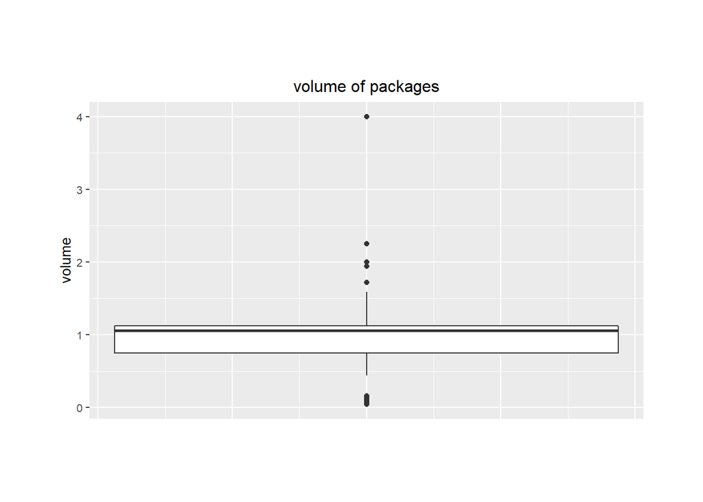

```r
ggplot(data = df) +
  geom_boxplot(mapping = aes(x = 1,y = volume))+
  ggtitle('volume of packages')+
  labs(x = '', y = 'volume')+
  theme(axis.title.x=element_blank(),
        axis.text.x=element_blank(),
        axis.ticks.x=element_blank(),#delete the x axis lables
        plot.title = element_text(hjust = 0.5),# title center
        text =  element_text(size=10),plot.margin = margin(2,1.5,2,1.5, "cm"))
```

Confirms The distribution of volume is skewed:

will use median instead of mean

There are outliers of volume 0 and above 1.5

## 4.2 Categorical variable

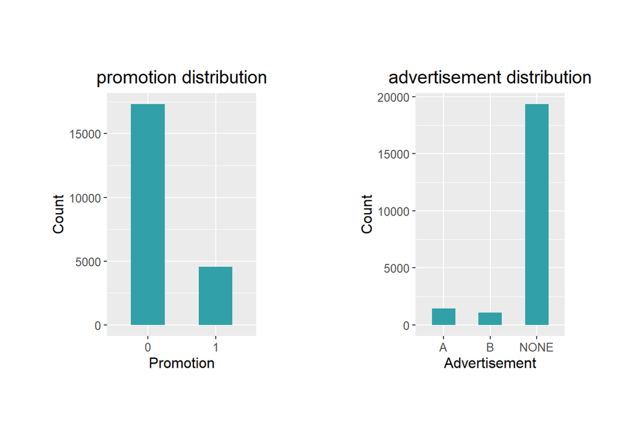

```r
grid.arrange(
  ggplot(data = df, mapping = aes(x = promo ))+
  geom_bar(width=0.5,fill = '#32a0a8')+
  ggtitle('promotion distribution')+
  labs(x = 'Promotion', y = 'Count')+
  theme(plot.title = element_text(hjust = 0.5,size= 15),text = element_text(size= 12),plot.margin = margin(2,1.5,2,1.5, "cm")),

  ggplot(data = df, mapping = aes(x = ad ))+
  geom_bar(width=0.5,fill = '#32a0a8')+
  ggtitle('advertisement distribution')+
  labs(x = 'Advertisement', y = 'Count')+
  theme(plot.title = element_text(hjust = 0.5,size= 15),text = element_text(size= 12),plot.margin = margin(2,1.5,2,1.5, "cm")),
  ncol=2

)
```

From the two graphs, we see that promotion and advertisement might not have such a big impact on revenue.Lets look at some more categorical variables

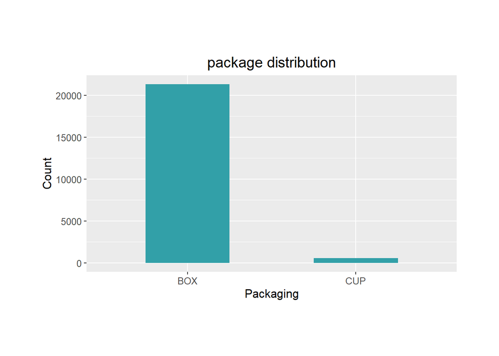

```r
grid.arrange(
  ggplot(data = df, mapping = aes(x = package ))+
  geom_bar(width=0.5,fill = '#32a0a8')+
  ggtitle('package distribution')+
  labs(x = 'Packaging', y = 'Count')+
  theme(plot.title = element_text(hjust = 0.5,size= 15),text = element_text(size= 12),plot.margin = margin(2,1.5,2,1.5, "cm"))

)
```

We see that box is the most popular packaging

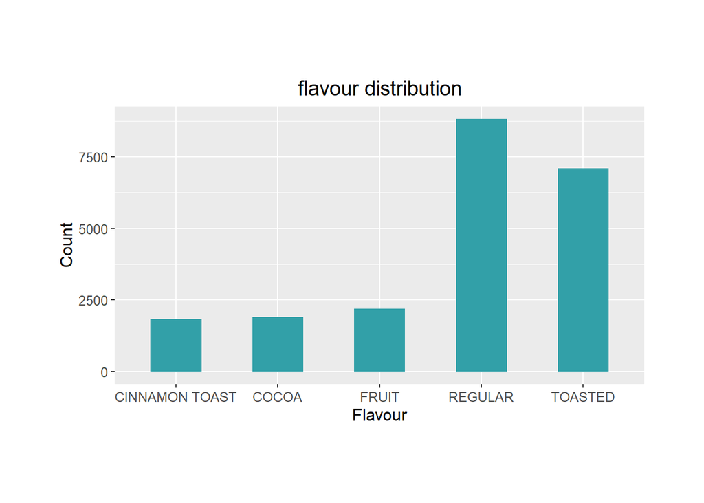

```r
ggplot(data = df, mapping = aes(x = flavor ))+
  geom_bar(width=0.5,fill = '#32a0a8')+
  ggtitle('flavour distribution')+
  labs(x = 'Flavour', y = 'Count')+
  theme(plot.title = element_text(hjust = 0.5,size= 15),text = element_text(size= 12),plot.margin = margin(2,1.5,2,1.5, "cm"))
```

We see that the most popular flavour is regular followed by toasted then fruit.

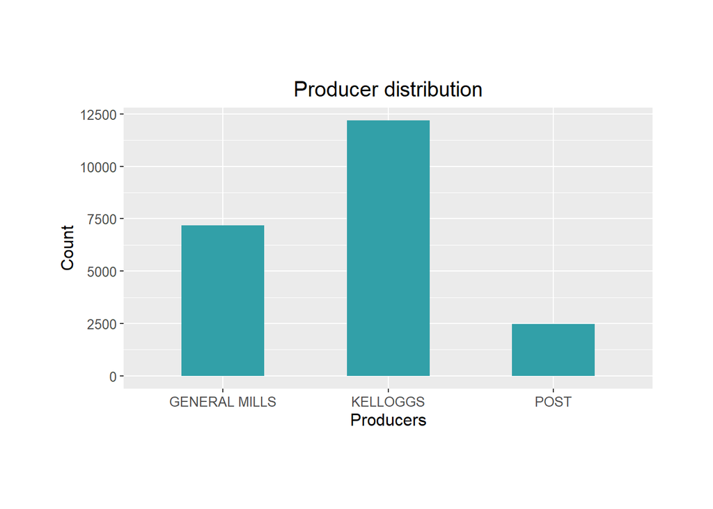

```r
ggplot(data = df, mapping = aes(x = Producers ))+
  geom_bar(width=0.5,fill = '#32a0a8')+
  ggtitle('Producer distribution')+
  labs(x = 'Producers', y = 'Count')+
  theme(plot.title = element_text(hjust = 0.5,size= 15),text = element_text(size= 12),plot.margin = margin(2,1.5,2,1.5, "cm"))
```

Comments: We will see later if brand or producers effect revenue,promotion,ads or prices.So far we see kellogss sells the most but we do not know how much of it has an impact.

# 5 Base EDA Step 3: Multivariate non-graphical

## 5.1 Categorical

```r
df %>%
  tabyl(promo,ad) %>%
  adorn_totals(where = c("row", "col"))
```

```
##  promo    A    B  NONE Total
##      0  683  402 16220 17305
##      1  773  659  3113  4545
##  Total 1456 1061 19333 21850
```

Comment: We see that most cereals do not have promo and ads, other than that promo with ads A gives the most sales.

```r
df %>%
  tabyl(promo,ad,flavor) %>%
  adorn_totals(where = c("row", "col"))
```

```
## $`CINNAMON TOAST`
##  promo   A  B NONE Total
##      0  60 24 1453  1537
##      1  54 27  216   297
##  Total 114 51 1669  1834
##
## $COCOA
##  promo   A  B NONE Total
##      0  45 21 1350  1416
##      1  83 70  332   485
##  Total 128 91 1682  1901
##
## $FRUIT
##  promo   A   B NONE Total
##      0  59  44 1570  1673
##      1  94  64  361   519
##  Total 153 108 1931  2192
##
## $REGULAR
##  promo   A   B NONE Total
##      0 231 161 6665  7057
##      1 285 278 1196  1759
##  Total 516 439 7861  8816
##
## $TOASTED
##  promo   A   B NONE Total
##      0 288 152 5182  5622
##      1 257 220 1008  1485
##  Total 545 372 6190  7107
```

Comments: We see that regular and toasted have the most ads and promos, so flavours could be having an effect on prices,promotions and ads

```r
df %>%
  tabyl(promo,ad,Producers) %>%
  adorn_totals(where = c("row", "col"))
```

```
## $`GENERAL MILLS`
##  promo   A   B NONE Total
##      0 218 100 5591  5909
##      1 224 172  884  1280
##  Total 442 272 6475  7189
##
## $KELLOGGS
##  promo   A   B  NONE Total
##      0 445 269  8756  9470
##      1 458 395  1860  2713
##  Total 903 664 10616 12183
##
## $POST
##  promo   A   B NONE Total
##      0  20  33 1873  1926
##      1  91  92  369   552
##  Total 111 125 2242  2478
```

Comment: From here, we are starting to see that the producer has effect on promo and ads, there are more promo and ads for kelloggs than general mills or post.

```r
df %>%
  tabyl(flavor,promo,Producers) %>%
  adorn_totals(where = c("row", "col"))
```

```
## $`GENERAL MILLS`
##          flavor    0    1 Total
##  CINNAMON TOAST 1537  297  1834
##           COCOA  769  251  1020
##           FRUIT    0    0     0
##         REGULAR 1004  199  1203
##         TOASTED 2599  533  3132
##           Total 5909 1280  7189
##
## $KELLOGGS
##          flavor    0    1 Total
##  CINNAMON TOAST    0    0     0
##           COCOA  647  234   881
##           FRUIT 1673  519  2192
##         REGULAR 4127 1008  5135
##         TOASTED 3023  952  3975
##           Total 9470 2713 12183
##
## $POST
##          flavor    0   1 Total
##  CINNAMON TOAST    0   0     0
##           COCOA    0   0     0
##           FRUIT    0   0     0
##         REGULAR 1926 552  2478
##         TOASTED    0   0     0
##           Total 1926 552  2478
```

Comments: +General Mills promote toasted flavour cereal more over regular where Kelloggs promotes regular over toasted. +Post only sells regular, but promotes more regular cereals than general mills

```r
df %>%
  tabyl(brand,promo) %>%
  adorn_totals(where = c("row", "col"))
```

```
##                          brand     0    1 Total
##         GENERAL MILLS CHEERIOS  1240  218  1458
##  GENERAL MILLS CINNAMON TST CR  1537  297  1834
##      GENERAL MILLS COCOA PUFFS   769  251  1020
##              GENERAL MILLS KIX   997  199  1196
##     GENERAL MILLS LUCKY CHARMS  1366  315  1681
##        KELLOGGS COCOA KRISPIES   647  234   881
##           KELLOGGS FROOT LOOPS  1673  519  2192
##        KELLOGGS FROSTED FLAKES  1819  476  2295
##   KELLOGGS FROSTED MINI WHEATS  1248  326  1574
##           KELLOGGS RAISIN BRAN  1060  206  1266
##         KELLOGGS RICE KRISPIES  1162  288  1450
##           KELLOGGS SMART START   812  322  1134
##             KELLOGGS SPECIAL K  1049  342  1391
##                POST GRAPE NUTS  1002  287  1289
##            POST SHREDDED WHEAT   924  265  1189
##                          Total 17305 4545 21850
```

Comments: The brand names of general mills lucky charms, kelloggs froot loops and kelloggs frosted flakes seems to be being promoted more based on brand name. Want to verify if it is on brand name or promoted on flavour.

```r
df %>%
  tabyl(flavor,brand) %>%
  adorn_totals(where = c("row", "col"))
```

```
##          flavor GENERAL MILLS CHEERIOS GENERAL MILLS CINNAMON TST CR
##  CINNAMON TOAST                      0                          1834
##           COCOA                      0                             0
##           FRUIT                      0                             0
##         REGULAR                      4                             0
##         TOASTED                   1454                             0
##           Total                   1458                          1834
##  GENERAL MILLS COCOA PUFFS GENERAL MILLS KIX GENERAL MILLS LUCKY CHARMS
##                          0                 0                          0
##                       1020                 0                          0
##                          0                 0                          0
##                          0              1196                          3
##                          0                 0                       1678
##                       1020              1196                       1681
##  KELLOGGS COCOA KRISPIES KELLOGGS FROOT LOOPS KELLOGGS FROSTED FLAKES
```

[output cut: 27 more lines]

Comment: Froot loops are promoted based on brand name. Otherwise, it seems that producers focused on flavour have a bigger impact on promotion.

```r
df %>%
  tabyl(brand,ad) %>%
  adorn_totals(where = c("row", "col"))
```

```
##                          brand    A    B  NONE Total
##         GENERAL MILLS CHEERIOS   79   44  1335  1458
##  GENERAL MILLS CINNAMON TST CR  114   51  1669  1834
##      GENERAL MILLS COCOA PUFFS   76   54   890  1020
##              GENERAL MILLS KIX   70   54  1072  1196
##     GENERAL MILLS LUCKY CHARMS  103   69  1509  1681
##        KELLOGGS COCOA KRISPIES   52   37   792   881
##           KELLOGGS FROOT LOOPS  153  108  1931  2192
##        KELLOGGS FROSTED FLAKES  141  124  2030  2295
##   KELLOGGS FROSTED MINI WHEATS  127   88  1359  1574
##           KELLOGGS RAISIN BRAN   67   47  1152  1266
##         KELLOGGS RICE KRISPIES  114   88  1248  1450
##           KELLOGGS SMART START  124   90   920  1134
##             KELLOGGS SPECIAL K  125   82  1184  1391
##                POST GRAPE NUTS   46   63  1180  1289
##            POST SHREDDED WHEAT   65   62  1062  1189
##                          Total 1456 1061 19333 21850
```

Comment: we see that the general mill focus on advertising their brands of cinnamon toast and lucky charms with ad A. Kelloggs makes more ad A for froot loops,frosted flakes,mini wheats rice krispies,smart tart,special K and makes ad B also for froot loops,frosted lakes.

```r
df %>%
  tabyl(flavor,ad,Producers) %>%
  adorn_totals(where = c("row", "col"))
```

```
## $`GENERAL MILLS`
##          flavor   A   B NONE Total
##  CINNAMON TOAST 114  51 1669  1834
##           COCOA  76  54  890  1020
##           FRUIT   0   0    0     0
##         REGULAR  70  55 1078  1203
##         TOASTED 182 112 2838  3132
##           Total 442 272 6475  7189
##
## $KELLOGGS
##          flavor   A   B  NONE Total
##  CINNAMON TOAST   0   0     0     0
##           COCOA  52  37   792   881
##           FRUIT 153 108  1931  2192
##         REGULAR 335 259  4541  5135
##         TOASTED 363 260  3352  3975
##           Total 903 664 10616 12183
##
## $POST
##          flavor   A   B NONE Total
##  CINNAMON TOAST   0   0    0     0
##           COCOA   0   0    0     0
##           FRUIT   0   0    0     0
##         REGULAR 111 125 2242  2478
##         TOASTED   0   0    0     0
##           Total 111 125 2242  2478
```

Comments:

Kellogs have more ads overall and more ads on toasted,regular,fruit than general mills who focuse ads on cinnamon toast and cocoa.

Post runs more ads on regular than general mills.

Questions:we can investigate on weekly basis to see when promos and ads are put up and compare them amongst themselves.

## 5.2 Quantitative

```r
df %>%
  select_if(is.numeric) %>% # Use to select just the numeric variables
  cor() %>%
  round(2) %>%
  kable()
```

|  | iri_key | units | volume | price | revenue |
| --- | --- | --- | --- | --- | --- |
| iri_key | 1.00 | 0.03 | -0.01 | -0.01 | 0.03 |
| units | 0.03 | 1.00 | 0.02 | -0.19 | 0.88 |
| volume | -0.01 | 0.02 | 1.00 | 0.54 | 0.21 |
| price | -0.01 | -0.19 | 0.54 | 1.00 | 0.18 |
| revenue | 0.03 | 0.88 | 0.21 | 0.18 | 1.00 |

comment:We can see that revenue has a high positive correaltion with units sold rather than price and volume.

# 6 Base EDA Step 4: Multi-variate graphical analysis

## 6.1 Categorical

We want to see deeper into the weekly promos and ads for each brand from each producer.

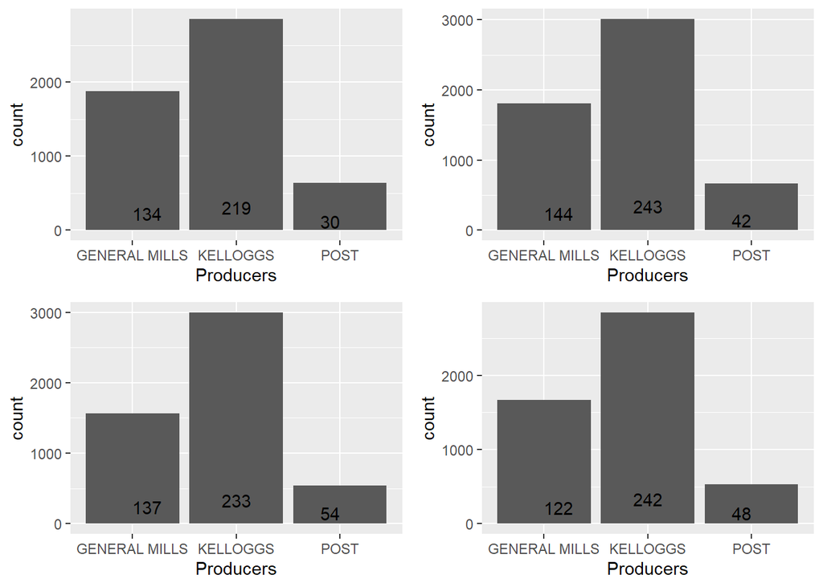

```r
grid.arrange(
   df %>%
filter(as.integer(week)<14) %>%
  group_by(Producers,week) %>%
  summarize(count=n()) %>%
  ggplot(aes(x = Producers, y = count)) + geom_bar(stat = "identity")+
  geom_text(aes(label = count),
            angle=0,vjust="inward",hjust="inward",check_overlap = TRUE),

 df %>%
   filter(as.integer(week)<27 & as.integer(week)>13 ) %>%
group_by(Producers,week) %>%
summarize(count=n()) %>%
ggplot(aes(x = Producers, y = count)) + geom_bar(stat = "identity")+
  geom_text(aes(label = count),
            angle=0,vjust="inward",hjust="inward",check_overlap = TRUE),

df %>%
   filter(as.integer(week)<40 & as.integer(week)>27 ) %>%
group_by(Producers,week) %>%
summarize(count=n()) %>%
ggplot(aes(x = Producers, y = count)) + geom_bar(stat = "identity")+
  geom_text(aes(label = count),
            angle=0,vjust="inward",hjust="inward",check_overlap = TRUE),

df %>%
   filter(as.integer(week)<53 & as.integer(week)>40) %>%
group_by(Producers,week) %>%
summarize(count=n()) %>%
ggplot(aes(x = Producers, y = count)) + geom_bar(stat = "identity")+
  geom_text(aes(label = count),
            angle=0,vjust="inward",hjust="inward",check_overlap = TRUE)
)
```

Comment: We do not really see a big difference in quarterly sales between the producers

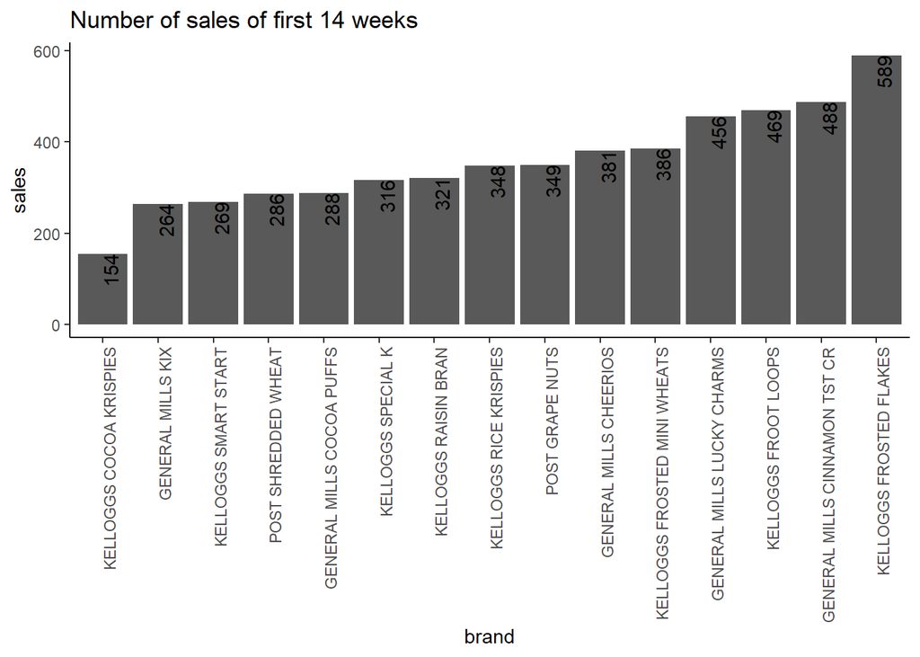

```r
df %>%
filter(as.integer(week)<14) %>%
  group_by(brand) %>%
  summarize(count=n()) %>%
  ggplot(aes(reorder(x = brand,count), y = count)) + geom_bar(stat = "identity")+
  geom_text(aes(label = count),
            angle=90,vjust=1,hjust=1,check_overlap = TRUE)+
  theme_classic()+
  theme(
       axis.text.x = element_text(angle=90, hjust=1)
  )+
  labs(title = "Number of sales of first 14 weeks",
       y = "sales",x="brand")
```

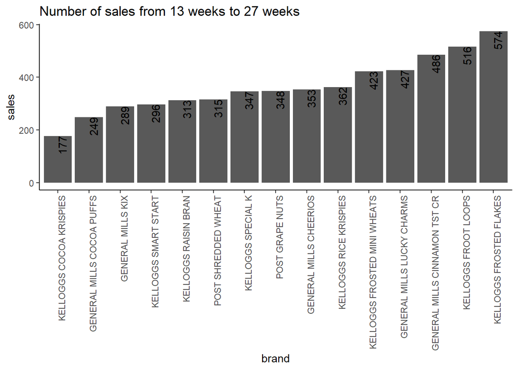

```r
 df %>%
   filter(as.integer(week)<27 & as.integer(week)>13 ) %>%
group_by(brand) %>%
summarize(count=n()) %>%
ggplot(aes(reorder(x = brand,count) ,y = count)) + geom_bar(stat = "identity")+
  geom_text(aes(label = count),
            angle=90,vjust=1,hjust=1,check_overlap = TRUE)+
   theme_classic()+
   theme(
       axis.text.x = element_text(angle=90, hjust=1)
  )+
  labs(title = "Number of sales from 13 weeks to 27 weeks",
       y = "sales",x="brand")
```

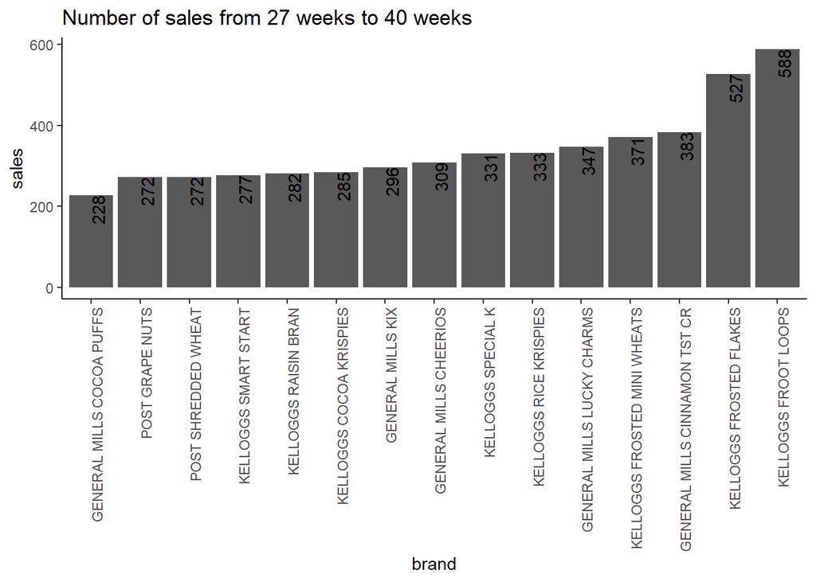

```r
df %>%
   filter(as.integer(week)<40 & as.integer(week)>27 ) %>%
group_by(brand) %>%
summarize(count=n()) %>%
ggplot(aes(reorder(x = brand,count), y = count)) + geom_bar(stat = "identity")+
  geom_text(aes(label = count),
            angle=90,vjust=1,hjust=1,check_overlap = TRUE)+
  theme_classic()+
  theme(
       axis.text.x = element_text(angle=90, hjust=1)
  )+
  labs(title = "Number of sales from 27 weeks to 40 weeks",
       y = "sales",x="brand")
```

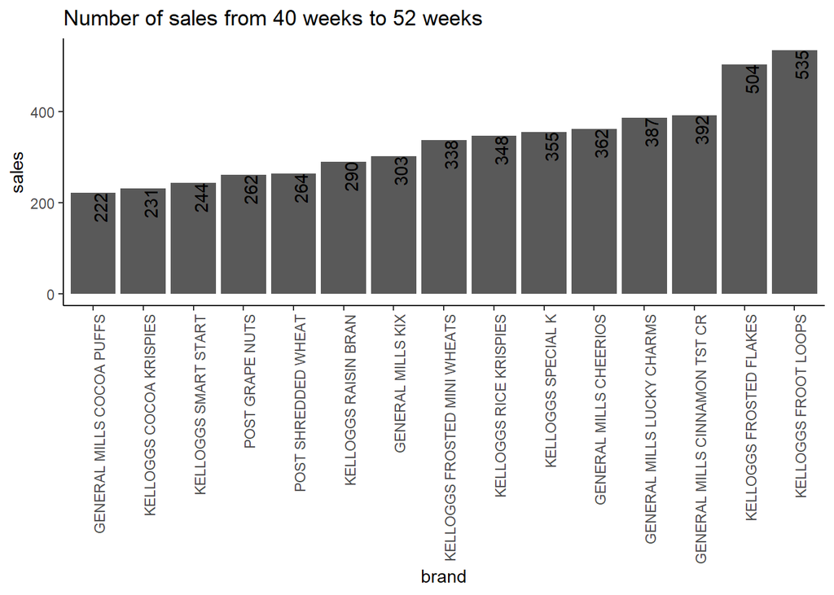

```r
df %>%
   filter(as.integer(week)<53 & as.integer(week)>40) %>%
group_by(brand) %>%
summarize(count=n()) %>%
ggplot(aes(reorder(x = brand,count) ,y = count)) + geom_bar(stat = "identity")+
  geom_text(aes(label = count),
            angle=90,vjust=1,hjust=1,check_overlap = TRUE)+
  theme_classic()+
  theme(
       axis.text.x = element_text(angle=90, hjust=1))+
   labs(title = "Number of sales from 40 weeks to 52 weeks",
       y = "sales",x="brand")
```

Comment: We can see there is a difference in the histogram as we move from one quarter sales to the others. I think sales are affected by brand rather than producer.

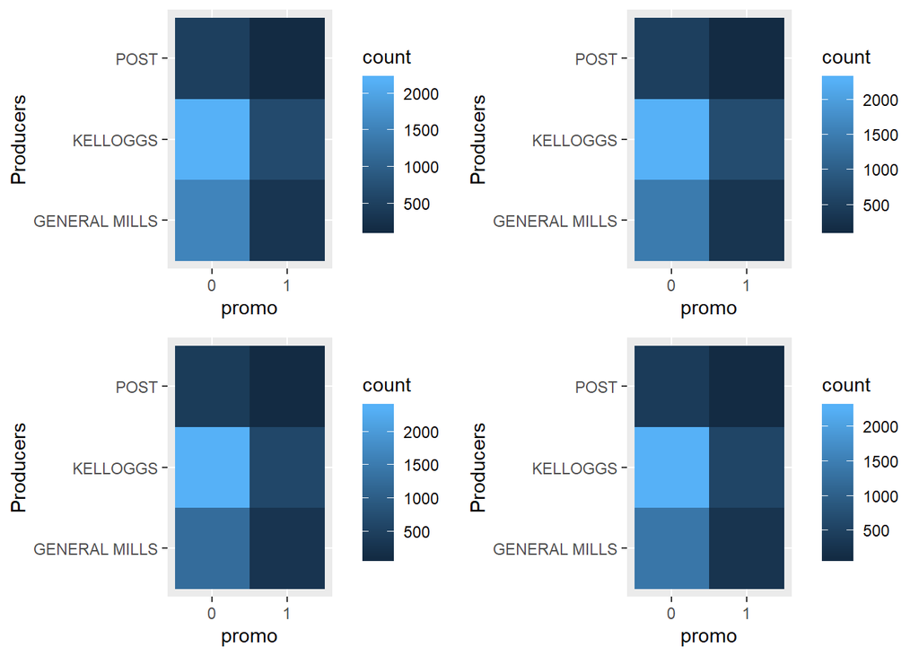

```r
grid.arrange(
  df %>% filter(as.integer(week)<14 )%>%
     group_by(promo, Producers) %>%
     summarise(count = n()) %>%
     ggplot(aes(promo, Producers)) +
     geom_tile(aes(fill = count)),

  df %>% filter(as.integer(week)<27 & as.integer(week)>13 )%>%
     group_by(promo, Producers) %>%
     summarise(count = n()) %>%
     ggplot(aes(promo, Producers)) +
     geom_tile(aes(fill = count)),

df %>% filter(as.integer(week)<40 & as.integer(week)>27 )%>%
     group_by(promo, Producers) %>%
     summarise(count = n()) %>%
     ggplot(aes(promo, Producers)) +
     geom_tile(aes(fill = count)),

df %>% filter(as.integer(week)<53 & as.integer(week)>40 )%>%
     group_by(promo, Producers) %>%
     summarise(count = n()) %>%
     ggplot(aes(promo, Producers)) +
     geom_tile(aes(fill = count))
)
```

Comment: There is almost not difference between the quartly heat mapps for promotion. So promotion is probably more brand based than producer. Let check it out below:

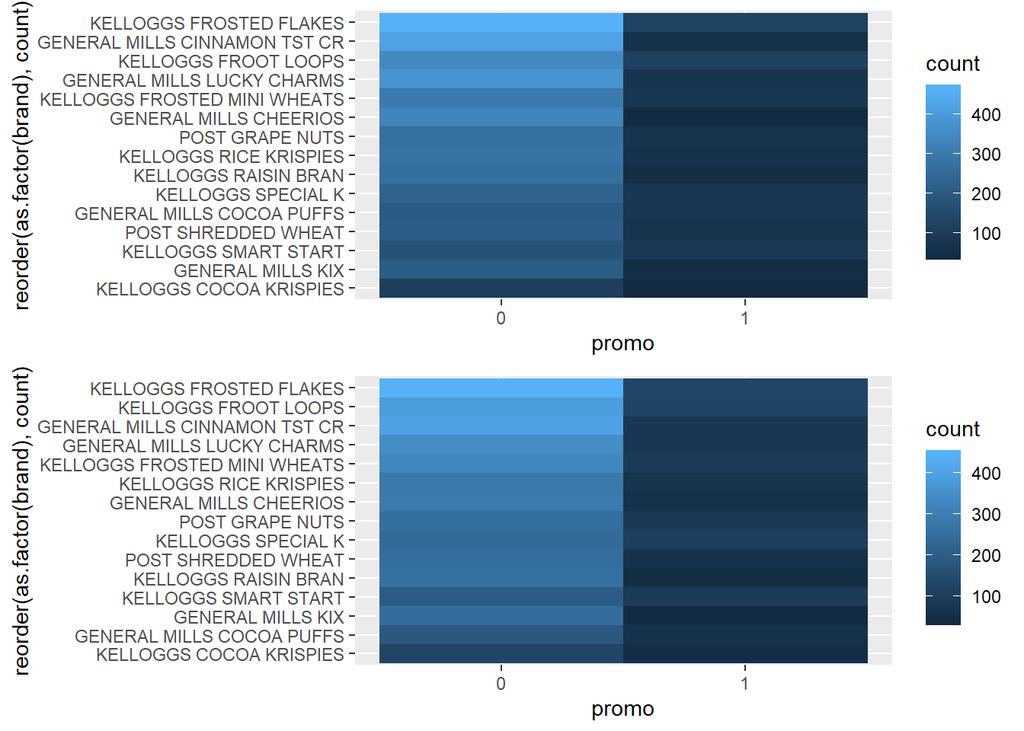

```r
grid.arrange(
  df %>% filter(as.integer(week)<14 )%>%
     group_by(promo, brand) %>%
     summarise(count = n()) %>%
     ggplot((aes(promo, reorder(as.factor(brand),count)))) +
     geom_tile(aes(fill = count)),

  df %>% filter(as.integer(week)<27 & as.integer(week)>13 )%>%
     group_by(promo, brand) %>%
     summarise(count = n()) %>%
     ggplot((aes(promo, reorder(as.factor(brand),count)))) +
     geom_tile(aes(fill = count)))
```

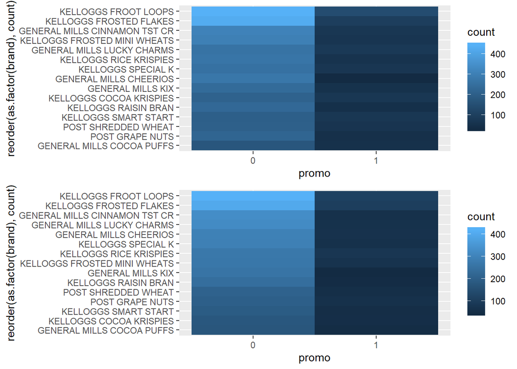

```r
grid.arrange(
df %>% filter(as.integer(week)<40 & as.integer(week)>27 )%>%
     group_by(promo, brand) %>%
     summarise(count = n()) %>%
     ggplot((aes(promo, reorder(as.factor(brand),count)))) +
     geom_tile(aes(fill = count)),

df %>% filter(as.integer(week)<53 & as.integer(week)>40 )%>%
     group_by(promo, brand) %>%
     summarise(count = n()) %>%
     ggplot((aes(promo, reorder(as.factor(brand),count)))) +
     geom_tile(aes(fill = count))
)
```

Comment: Comments: We can see that brands affect promoted over the quarters.We want to look at how each brand is being promoted over the 52 weeks.We will check it out later.

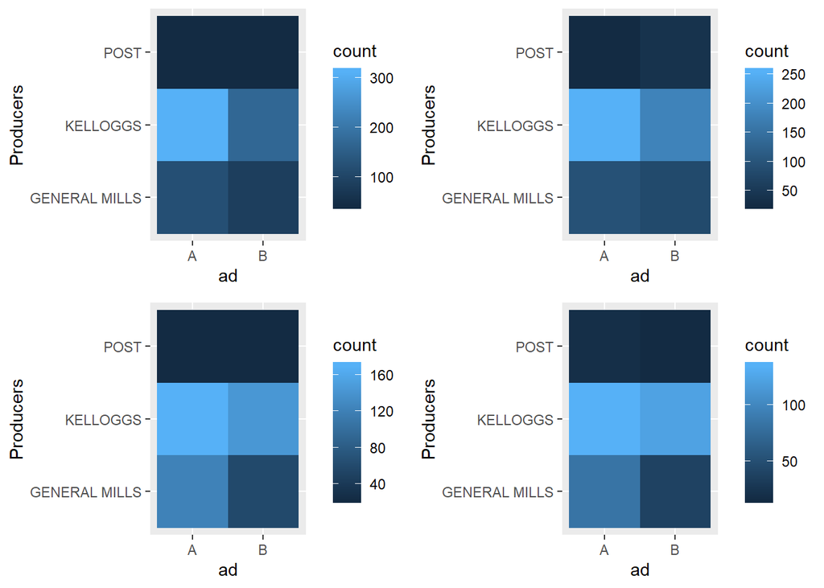

```r
grid.arrange(
  df %>% filter(as.integer(week)<14 & ad!="NONE")%>%
     group_by(ad, Producers) %>%
     summarise(count = n()) %>%
     ggplot(aes(ad, Producers)) +
     geom_tile(aes(fill = count)),

  df %>% filter(as.integer(week)<27 & as.integer(week)>13 & ad!="NONE" )%>%
     group_by(ad, Producers) %>%
     summarise(count = n()) %>%
     ggplot(aes(ad, Producers)) +
     geom_tile(aes(fill = count)),

df %>% filter(as.integer(week)<40 & as.integer(week)>27 & ad!= "NONE")%>%
     group_by(ad, Producers) %>%
     summarise(count = n()) %>%
     ggplot(aes(ad, Producers)) +
     geom_tile(aes(fill = count)),

df %>% filter(as.integer(week)<53 & as.integer(week)>40 & ad!="NONE")%>%
     group_by(ad, Producers) %>%
     summarise(count = n()) %>%
     ggplot(aes(ad, Producers)) +
     geom_tile(aes(fill = count))
)
```

Comment: Yet again, producers do not really have an impact on ads quaterly

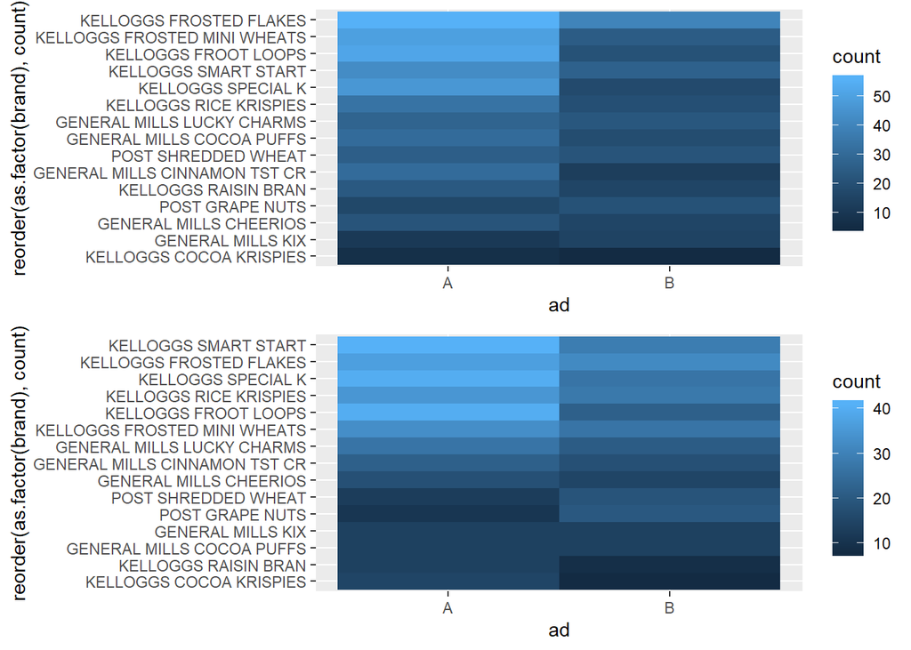

```r
grid.arrange(
  df %>% filter(as.integer(week)<14 & ad!="NONE"  )%>%
     group_by(ad, brand) %>%
     summarise(count = n()) %>%
     ggplot(aes(ad, reorder(as.factor(brand),count))) +
     geom_tile(aes(fill = count)),

  df %>% filter(as.integer(week)<27 & as.integer(week)>13 & ad!="NONE" )%>%
     group_by(ad, brand) %>%
     summarise(count = n()) %>%
     ggplot(aes(ad, reorder(as.factor(brand),count))) +
     geom_tile(aes(fill = count)))
```

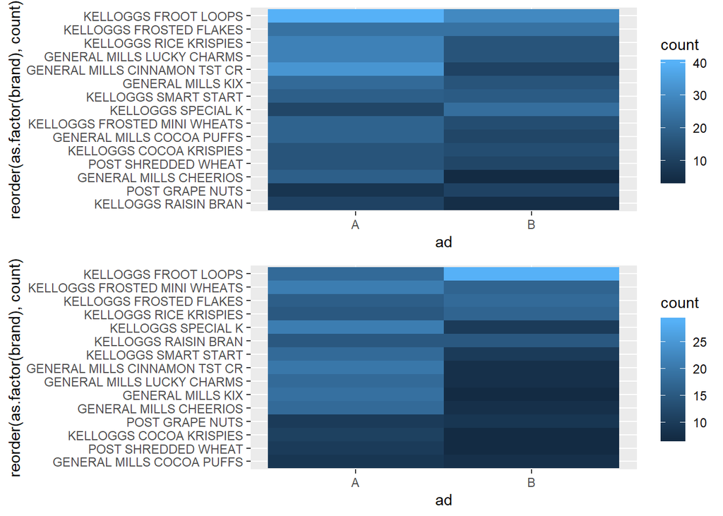

```r
grid.arrange(
df %>% filter(as.integer(week)<40 & as.integer(week)>27 & ad!= "NONE")%>%
     group_by(ad, brand) %>%
     summarise(count = n()) %>%
     ggplot(aes(ad, reorder(as.factor(brand),count))) +
     geom_tile(aes(fill = count)),

df %>% filter(as.integer(week)<53 & as.integer(week)>40 & ad!="NONE")%>%
     group_by(ad, brand) %>%
     summarise(count = n()) %>%
     ggplot(aes(ad, reorder(as.factor(brand),count))) +
     geom_tile(aes(fill = count))
)
```

Comments: We can see that brands affect ads over the quarters. We need to now carefully see for each producers’ brands how do they affect advertisement?

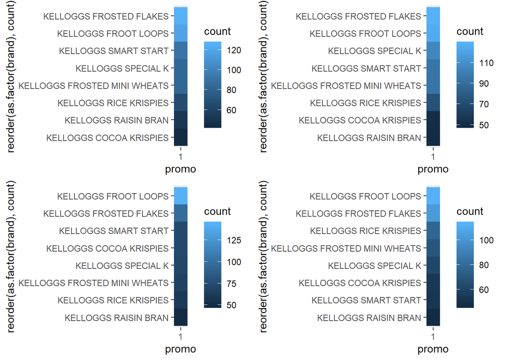

```r
grid.arrange(
  df %>% filter(as.integer(week)<14 & str_detect(df$brand, "KELLOGGS" )& promo!="0")%>%
     group_by(promo, brand) %>%
     summarise(count = n()) %>%
     ggplot((aes(promo, reorder(as.factor(brand),count)))) +
     geom_tile(aes(fill = count)),

  df %>% filter(as.integer(week)<27 & as.integer(week)>13 & str_detect(df$brand, "KELLOGGS") & promo!="0")%>%
     group_by(promo, brand) %>%
     summarise(count = n()) %>%
     ggplot((aes(promo, reorder(as.factor(brand),count)))) +
     geom_tile(aes(fill = count)),
df %>% filter(as.integer(week)<40 & as.integer(week)>27 & str_detect(df$brand, "KELLOGGS")& promo!="0")%>%
     group_by(promo, brand) %>%
     summarise(count = n()) %>%
     ggplot((aes(promo, reorder(as.factor(brand),count)))) +
     geom_tile(aes(fill = count)),

df %>% filter(as.integer(week)<53 & as.integer(week)>40 & str_detect(df$brand, "KELLOGGS")& promo!="0")%>%
     group_by(promo, brand) %>%
     summarise(count = n()) %>%
     ggplot((aes(promo, reorder(as.factor(brand),count)))) +
     geom_tile(aes(fill = count))
)
```

Comment:

For the first 26 weeks, there were promotion across the brand. But for the third quarter of weeks, the promotion was mostly based on froot loop.

raisin brian remained low promoted through the 52 weeks

for the the last 26 weeks, froot loops were promoted more than frosted lakes

Cocoa krispies were promoted more compared to the first two quarters

special k was promoted less on the last two quarters

promotion of rice krispies and mini wheats rose in the last quarter

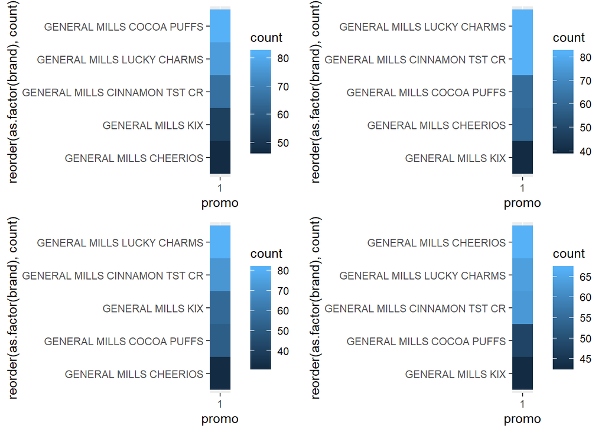

```r
grid.arrange(
  df %>% filter(as.integer(week)<14 & str_detect(df$brand, "GENERAL MILLS" )& promo!="0")%>%
     group_by(promo, brand) %>%
     summarise(count = n()) %>%
     ggplot((aes(promo, reorder(as.factor(brand),count)))) +
     geom_tile(aes(fill = count)),

  df %>% filter(as.integer(week)<27 & as.integer(week)>13 & str_detect(df$brand, "GENERAL MILLS") & promo!="0")%>%
     group_by(promo, brand) %>%
     summarise(count = n()) %>%
     ggplot((aes(promo, reorder(as.factor(brand),count)))) +
     geom_tile(aes(fill = count)),
df %>% filter(as.integer(week)<40 & as.integer(week)>27 & str_detect(df$brand, "GENERAL MILLS")& promo!="0")%>%
     group_by(promo, brand) %>%
     summarise(count = n()) %>%
     ggplot((aes(promo, reorder(as.factor(brand),count)))) +
     geom_tile(aes(fill = count)),

df %>% filter(as.integer(week)<53 & as.integer(week)>40 & str_detect(df$brand, "GENERAL MILLS")& promo!="0")%>%
     group_by(promo, brand) %>%
     summarise(count = n()) %>%
     ggplot((aes(promo, reorder(as.factor(brand),count)))) +
     geom_tile(aes(fill = count))
)
```

Comments:

cocoa puffs have decreased in promotion after the first quarter

lucky charms were promoted well over the four quarters

cherrios were promoted heavily on the last quarter

toast CR was promoted consistently over the four quarters

Kix saw increase in promotion in the third quarter but fall back in the last quarter

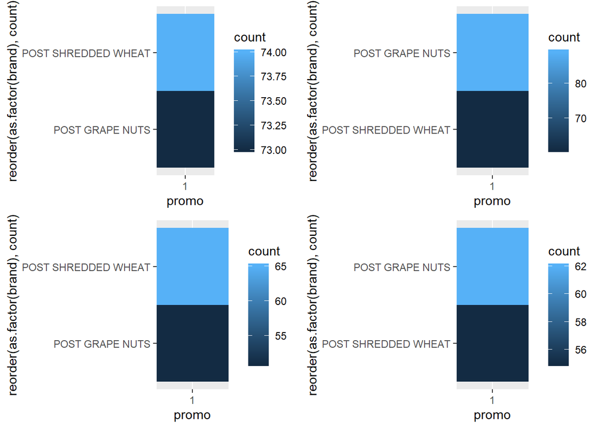

```r
grid.arrange(
  df %>% filter(as.integer(week)<14 & str_detect(df$brand, "POST" )& promo!="0")%>%
     group_by(promo, brand) %>%
     summarise(count = n()) %>%
     ggplot((aes(promo, reorder(as.factor(brand),count)))) +
     geom_tile(aes(fill = count)),

  df %>% filter(as.integer(week)<27 & as.integer(week)>13 & str_detect(df$brand, "POST") & promo!="0")%>%
     group_by(promo, brand) %>%
     summarise(count = n()) %>%
     ggplot((aes(promo, reorder(as.factor(brand),count)))) +
     geom_tile(aes(fill = count)),
df %>% filter(as.integer(week)<40 & as.integer(week)>27 & str_detect(df$brand, "POST")& promo!="0")%>%
     group_by(promo, brand) %>%
     summarise(count = n()) %>%
     ggplot((aes(promo, reorder(as.factor(brand),count)))) +
     geom_tile(aes(fill = count)),

df %>% filter(as.integer(week)<53 & as.integer(week)>40 & str_detect(df$brand, "POST")& promo!="0")%>%
     group_by(promo, brand) %>%
     summarise(count = n()) %>%
     ggplot((aes(promo, reorder(as.factor(brand),count)))) +
     geom_tile(aes(fill = count))
)
```

Comments: Post promotes grape nuts and shredded wheat alternatingly through the quarters of 52 weeks.

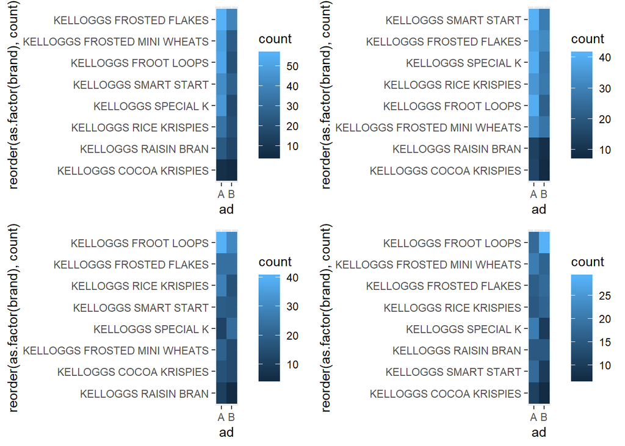

```r
grid.arrange(
  df %>% filter(as.integer(week)<14 & ad!="NONE" & str_detect(df$brand, "KELLOGGS") )%>%
     group_by(ad, brand) %>%
     summarise(count = n()) %>%
     ggplot(aes(ad, reorder(as.factor(brand),count))) +
     geom_tile(aes(fill = count)),

  df %>% filter(as.integer(week)<27 & as.integer(week)>13 & ad!="NONE" & str_detect(df$brand, "KELLOGGS"))%>%
     group_by(ad, brand) %>%
     summarise(count = n()) %>%
     ggplot(aes(ad, reorder(as.factor(brand),count))) +
     geom_tile(aes(fill = count)),
df %>% filter(as.integer(week)<40 & as.integer(week)>27 & ad!= "NONE" & str_detect(df$brand, "KELLOGGS"))%>%
     group_by(ad, brand) %>%
     summarise(count = n()) %>%
     ggplot(aes(ad, reorder(as.factor(brand),count))) +
     geom_tile(aes(fill = count)),

df %>% filter(as.integer(week)<53 & as.integer(week)>40 & ad!="NONE" & str_detect(df$brand, "KELLOGGS"))%>%
     group_by(ad, brand) %>%
     summarise(count = n()) %>%
     ggplot(aes(ad, reorder(as.factor(brand),count))) +
     geom_tile(aes(fill = count))
)
```

Comment:

cocoa krispies and raisin brian are the least advertised throughout the four quarters

in the second quarter smart start was advertised a lot with ad A but after and including the third quarter,kelloggs decreased in advertising

in the first two quarters, special K was advertised a lot with ad A but was advertised with ad B in the third quarter and then back to ad A in the last quarter

froot loop was advertised with ad A for the first three quarters but then kelloggs switched to advertising with ad B

mini wheats was advertised with ad A, then fell for the next two quarters and rose back again in the last quarter

rice krispies advertisement didn’t vary so much among the quarters and between ads

frosted flakes was advertised the most in the first quarter by ad A and then fell in advertising in both A and B

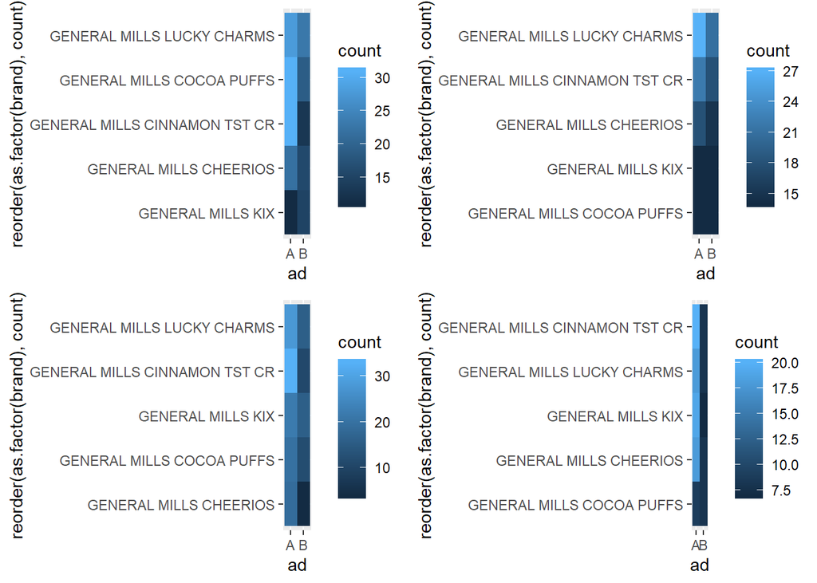

```r
grid.arrange(
  df %>% filter(as.integer(week)<14 & ad!="NONE" & str_detect(df$brand, "GENERAL MILLS") )%>%
     group_by(ad, brand) %>%
     summarise(count = n()) %>%
     ggplot(aes(ad, reorder(as.factor(brand),count))) +
     geom_tile(aes(fill = count)),

  df %>% filter(as.integer(week)<27 & as.integer(week)>13 & ad!="NONE" & str_detect(df$brand, "GENERAL MILLS"))%>%
     group_by(ad, brand) %>%
     summarise(count = n()) %>%
     ggplot(aes(ad, reorder(as.factor(brand),count))) +
     geom_tile(aes(fill = count)),
df %>% filter(as.integer(week)<40 & as.integer(week)>27 & ad!= "NONE" & str_detect(df$brand, "GENERAL MILLS"))%>%
     group_by(ad, brand) %>%
     summarise(count = n()) %>%
     ggplot(aes(ad, reorder(as.factor(brand),count))) +
     geom_tile(aes(fill = count)),

df %>% filter(as.integer(week)<53 & as.integer(week)>40 & ad!="NONE" & str_detect(df$brand, "GENERAL MILLS"))%>%
     group_by(ad, brand) %>%
     summarise(count = n()) %>%
     ggplot(aes(ad, reorder(as.factor(brand),count))) +
     geom_tile(aes(fill = count))
)
```

Comment:

Compared to Kelloggs, General Mill uses more of the ad A for its brands throughout the 52 weeks

cocoa puffs were advertised with ad A and then was not advertised much anymore throughout the last 3 quarters

lucky charms is advertised frequently throughout the four quarters with ad A

Mill Kix have been advertised more with ad A in the last two quarters

Cinnamon Toast have been consistently advertised more with ad A, in quarter four being the most advertised

Cheerios have not been advertised as much relatively to other brad in general mills.

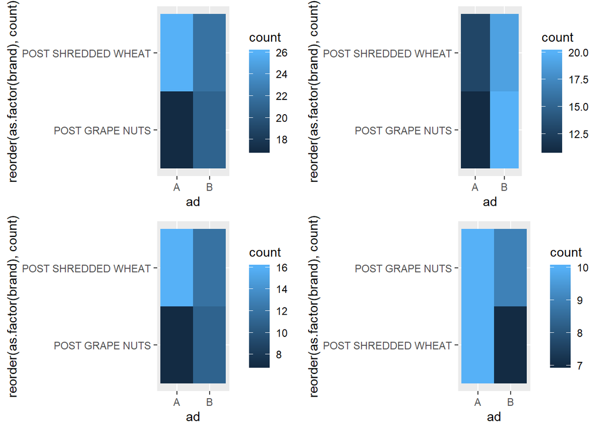

```r
grid.arrange(
  df %>% filter(as.integer(week)<14 & ad!="NONE" & str_detect(df$brand, "POST") )%>%
     group_by(ad, brand) %>%
     summarise(count = n()) %>%
     ggplot(aes(ad, reorder(as.factor(brand),count))) +
     geom_tile(aes(fill = count)),

  df %>% filter(as.integer(week)<27 & as.integer(week)>13 & ad!="NONE" & str_detect(df$brand, "POST"))%>%
     group_by(ad, brand) %>%
     summarise(count = n()) %>%
     ggplot(aes(ad, reorder(as.factor(brand),count))) +
     geom_tile(aes(fill = count)),
df %>% filter(as.integer(week)<40 & as.integer(week)>27 & ad!= "NONE" & str_detect(df$brand, "POST"))%>%
     group_by(ad, brand) %>%
     summarise(count = n()) %>%
     ggplot(aes(ad, reorder(as.factor(brand),count))) +
     geom_tile(aes(fill = count)),

df %>% filter(as.integer(week)<53 & as.integer(week)>40 & ad!="NONE" & str_detect(df$brand, "POST"))%>%
     group_by(ad, brand) %>%
     summarise(count = n()) %>%
     ggplot(aes(ad, reorder(as.factor(brand),count))) +
     geom_tile(aes(fill = count))
)
```

Comment:

for the first quarter, ad A were used more. Post advertised shredded whear more than grape nuts

for the second quarter, Post used ad b more. They advertised grape nuts more than shredded wheat

for the third quarter, Post went back to ad A and advertised shredded wheat more

For the fourth quarter, ad A were used more to advertise both shredded wheat and grape nuts equally.

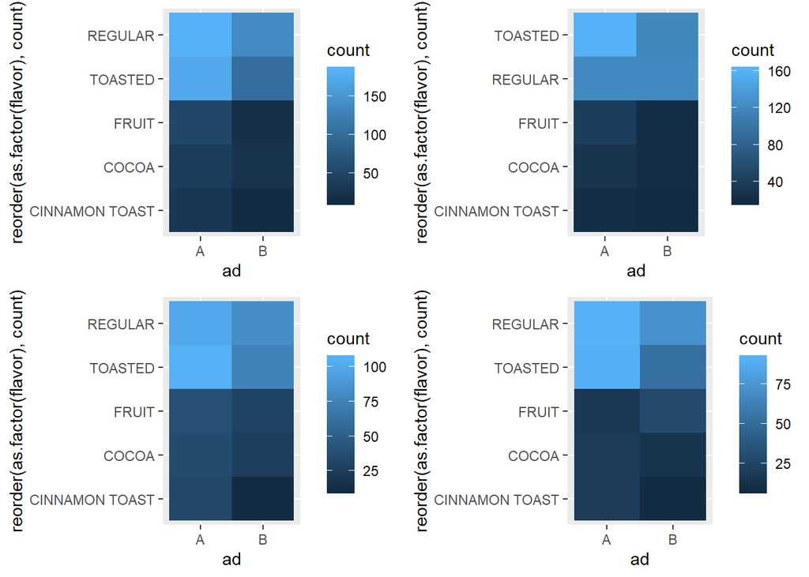

```r
grid.arrange(
  df %>% filter(as.integer(week)<14 & ad!="NONE"  )%>%
     group_by(ad, flavor) %>%
     summarise(count = n()) %>%
     ggplot(aes(ad, reorder(as.factor(flavor),count))) +
     geom_tile(aes(fill = count)),

  df %>% filter(as.integer(week)<27 & as.integer(week)>13 & ad!="NONE" )%>%
     group_by(ad, flavor) %>%
     summarise(count = n()) %>%
     ggplot(aes(ad, reorder(as.factor(flavor),count))) +
     geom_tile(aes(fill = count)),
df %>% filter(as.integer(week)<40 & as.integer(week)>27 & ad!= "NONE" )%>%
     group_by(ad, flavor) %>%
     summarise(count = n()) %>%
     ggplot(aes(ad, reorder(as.factor(flavor),count))) +
     geom_tile(aes(fill = count)),

df %>% filter(as.integer(week)<53 & as.integer(week)>40 & ad!="NONE")%>%
     group_by(ad, flavor) %>%
     summarise(count = n()) %>%
     ggplot(aes(ad, reorder(as.factor(flavor),count))) +
     geom_tile(aes(fill = count))
)
```

Comment:

We can see that the pattern doesn’t really change throughout the quarters and so we can say that brand name affects promo and ads rather than producer and flavors.

## 6.2 Quantitative

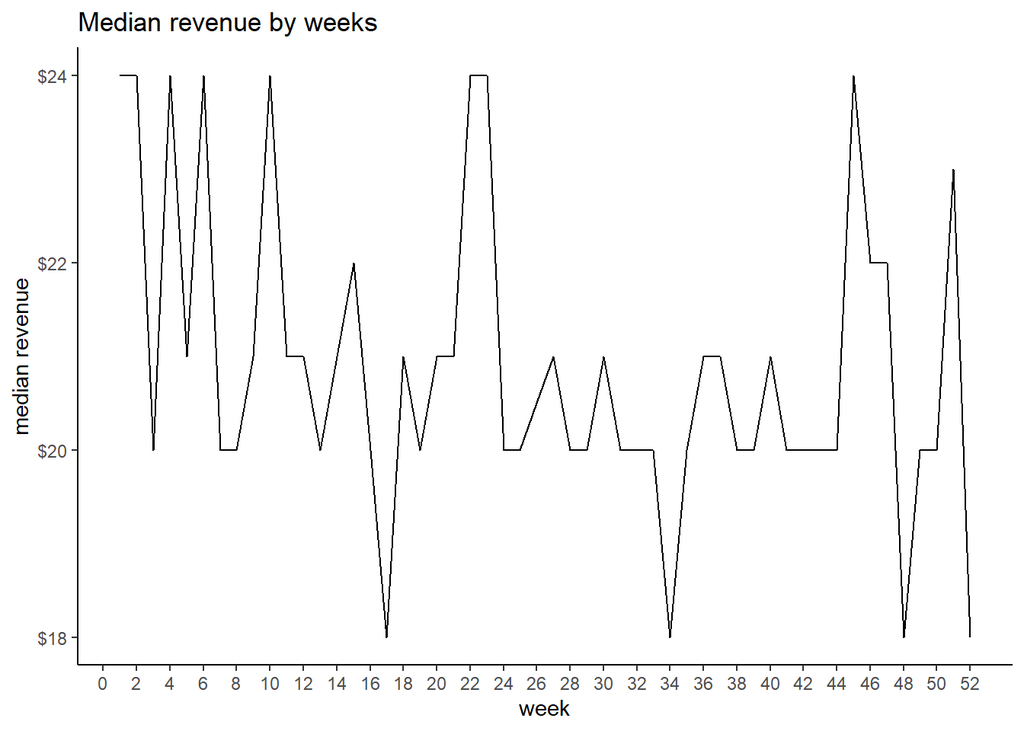

```r
df %>%
  group_by(week) %>%
  summarize(med_rev = median(revenue)) %>%
  ggplot(mapping = aes(x = as.integer(week), y = med_rev)) +
  geom_line()+
  scale_y_continuous(labels=scales::dollar)+
  theme_classic()+
  scale_x_continuous(breaks=seq(0,52,by=2))+
  labs(title = "Median revenue by weeks",
       x = "week",
       y = "median revenue")
```

Comment:

We see a drop in median revenue at 17 week, at 34 and at 48. What can cause this?

We see five big peaks, what which brands causes this peak? Is promo and ad helping?How is general mills share in these revenue peaks?

## 6.3 Quantitative and Categorical

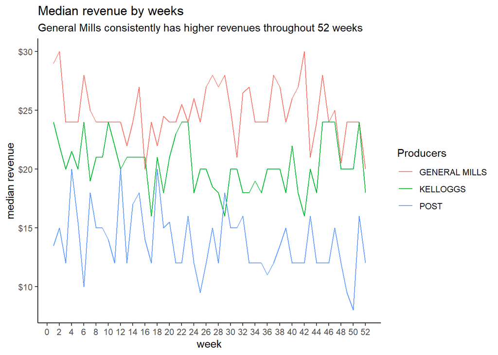

```r
line_graph_3firm<-df %>%
  group_by(week,Producers) %>%
  summarize(med_rev = median(revenue)) %>%
  ggplot(mapping = aes(x = as.integer(week), y = med_rev,colour=Producers)) +
  geom_line()+
  scale_y_continuous(labels=scales::dollar)+
  theme_classic()+
  scale_x_continuous(breaks=seq(0,52,by=2))+
  labs(title = "Median revenue by weeks",
       subtitle = "General Mills consistently has higher revenues throughout 52 weeks",
       x = "week",
       y = "median revenue")
line_graph_3firm
```

```r
ggsave(filename = "line_graph_3firm.png", plot = line_graph_3firm)
```

Comment:

We can see that overall General Mills have been earning more revenue than kelloggs and post.

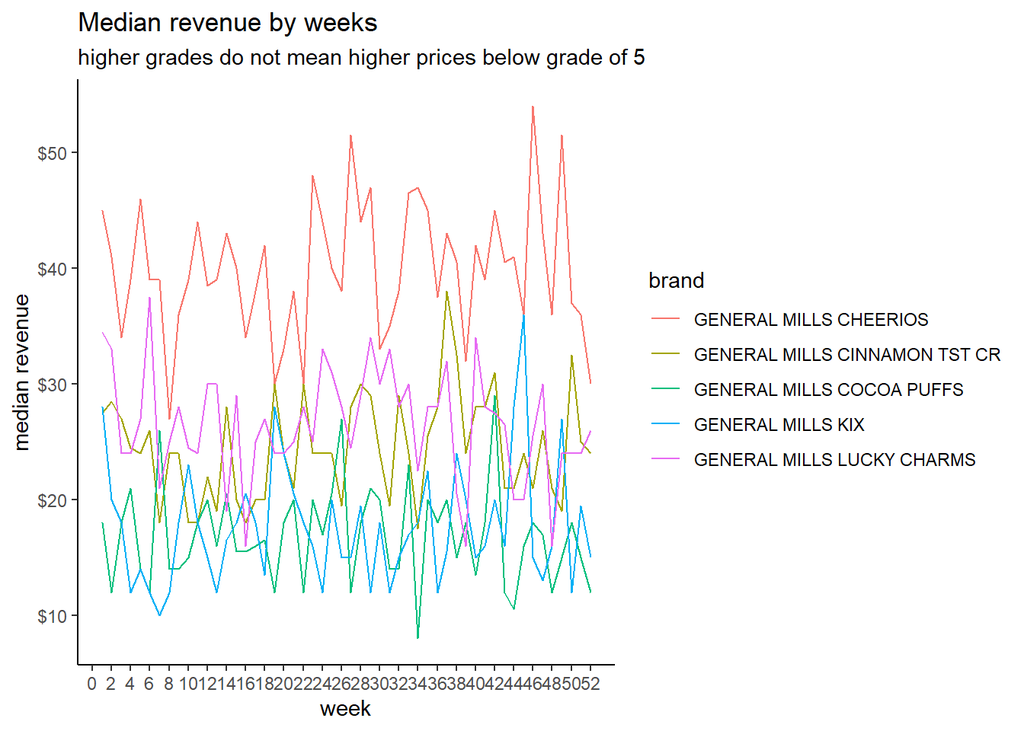

```r
df %>%
  filter(str_detect(df$brand, "GENERAL MILLS"))%>%
  group_by(week,brand) %>%
  summarize(med_rev = median(revenue)) %>%
  ggplot(mapping = aes(x = as.integer(week), y = med_rev,colour=brand)) +
  geom_line()+
  scale_y_continuous(labels=scales::dollar)+
  theme_classic()+
  scale_x_continuous(breaks=seq(0,52,by=2))+
  labs(title = "Median revenue by weeks",
       subtitle = "higher grades do not mean higher prices below grade of 5",
       x = "week",
       y = "median revenue")
```

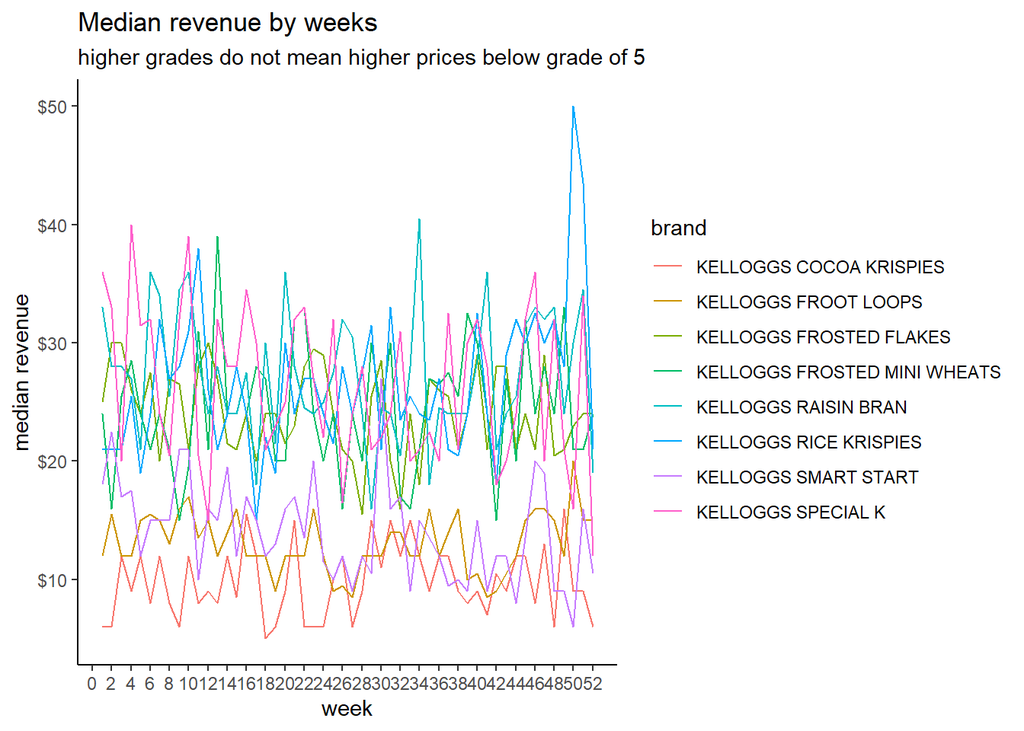

```r
df %>%
  filter(str_detect(df$brand, "KELLOGGS"))%>%
  group_by(week,brand) %>%
  summarize(med_rev = median(revenue)) %>%
  ggplot(mapping = aes(x = as.integer(week), y = med_rev,colour=brand)) +
  geom_line()+
  scale_y_continuous(labels=scales::dollar)+
  theme_classic()+
  scale_x_continuous(breaks=seq(0,52,by=2))+
  labs(title = "Median revenue by weeks",
       subtitle = "higher grades do not mean higher prices below grade of 5",
       x = "week",
       y = "median revenue")
```

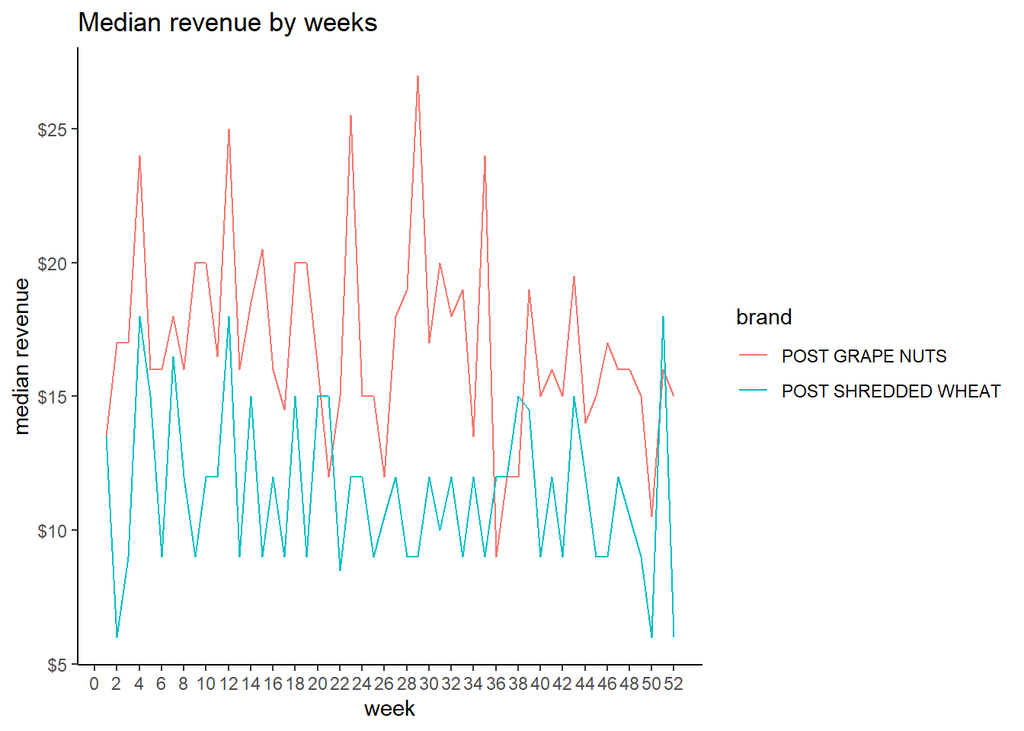

```r
df %>%
  filter(str_detect(df$brand, "POST"))%>%
  group_by(week,brand) %>%
  summarize(med_rev = median(revenue)) %>%
  ggplot(mapping = aes(x = as.integer(week), y = med_rev,colour=brand)) +
  geom_line()+
  scale_y_continuous(labels=scales::dollar)+
  theme_classic()+
  scale_x_continuous(breaks=seq(0,52,by=2))+
  labs(title = "Median revenue by weeks",
       x = "week",
       y = "median revenue")
```

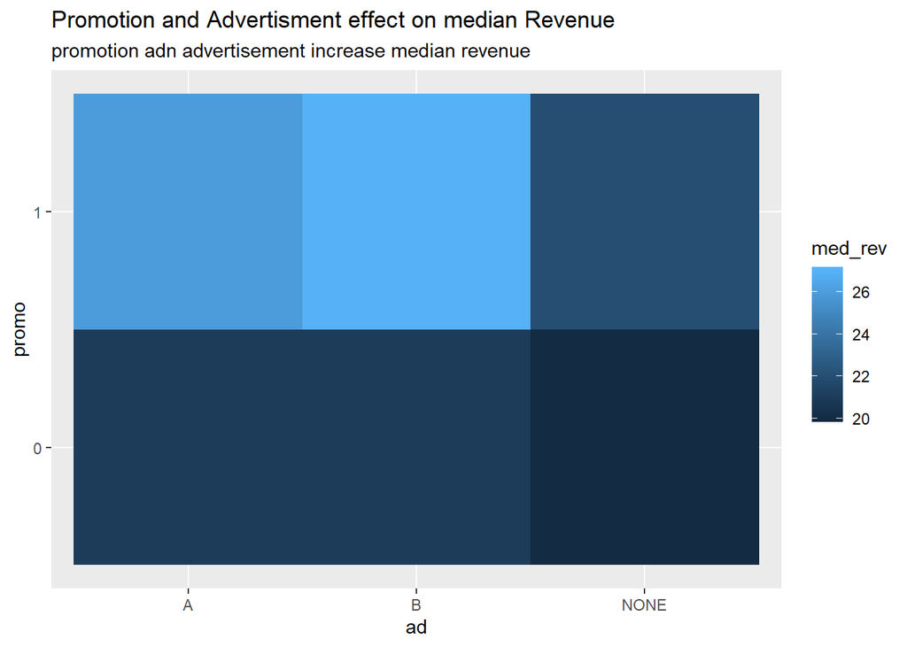

```r
Promo_ad_tile<-df %>%
group_by(ad, promo) %>%
  summarise(med_rev = median(revenue)) %>%
  ggplot(aes(ad, promo)) +
  geom_tile(aes(fill = med_rev))+
  labs(title = "Promotion and Advertisment effect on median Revenue",subtitle = "promotion adn advertisement increase median revenue")
ggsave(filename = "Promo_ad_tile.png", plot = Promo_ad_tile)
Promo_ad_tile
```

Comment: We can clearly see that Ad B with promo accounts for higher revenue. But which brands? and which parts of the weeks? Same for Ad A with promo.

# 7 Detailed EDA: questions raised in based EDA

## 7.1 which brand dominates in the flavour sector and earn highest total revenues throughout 52 weeks?

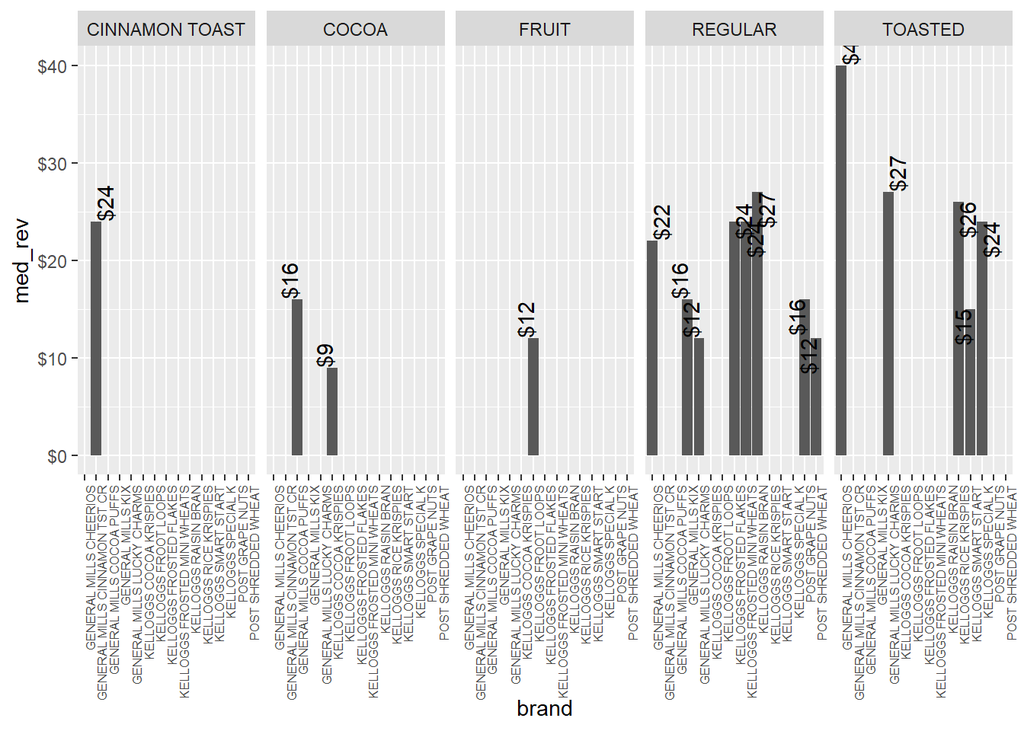

```r
df %>%
  group_by(brand,flavor)%>%
    summarize(med_rev=median(revenue),n_eth=n()) %>%
ggplot(aes(x = brand, y = med_rev)) + geom_bar(stat = "identity")+
    facet_wrap( ~ flavor,ncol = 5)+
   geom_text(aes(label = dollar(med_rev)),
            angle=90,vjust="inward",hjust="inward")+
  scale_y_continuous(labels=scales::dollar)+
  theme(
       axis.text.x = element_text(angle=90, hjust=1,size = 6)
  )
```